# Expose a network to data

(신경망에 데이터 보여주기?)

Your instructions will live in this notebook, and your workspace will be in DIGITS. You'll need to go back and forth between the two tabs. Open DIGITS in a separate tab, here:

(현재 보고있는 이 **"주피터 노트북"** 페이지와 **"DIGITS"** 페이지를 오가며 (체험?)을 하시게 됩니다. 아래의 링크로 DIGITS를 별도의 탭에 실행할 수 있습니다.)

### [DIGITS 열기](http://localhost:5000)

DIGITS 페이지에서 username을 입력하는 페이지가 나타나면 *'영문 소문자'* 만 사용해 username을 입력해 주시기 바랍니다.  
이후로 또 username을 입력하는 페이지가 나오면 **항상 같은 username**을 사용해 주시기 바랍니다.

[figure not shown]

이제 DIGITS 페이지에서 첫번째 (인공지능)모델을 만들어 보실 수 있습니다.  
**"New Model"** 글자 아래의 **"Images"** 버튼을 눌러 나오는 목록에서 **"Classification"** 을 선택합니다.

[figure not shown]

이후 표시되는 페이지에서 학습 할 조건을 설정할 수 있습니다.  
많은 옵션들이 보이지만 이번에는 간단하게 **Dataset**과 **학습시간** 학습 할 **신경망**, 세가지 조건만 선택해 시작 해 보도록 하겠습니다.

## 데이터셋 (Dataset)

신경망(인공지능)(네트워크)을 학습시키기 위해서는 **레이블 된 데이터**가 필요합니다.  
레이블 된 8개의 *Louie* 이미지와 8개의 *NotLouie* 이미지를 **"Image of Beagles"** 데이터셋에 미리 로드 해 두었습니다.

아래의 사진과 같이 선택할 수 있습니다,.

[figure not shown]

## 학습시간 (Training Time)

다음으로 DIGITS가 모든 이미지를 확인하고 학습할 횟수를 정해줍니다. 모든 데이터를 한차례 확인하고 학습하는 과정을 **에폭(epoch)** 이라고 부릅니다.  
이번에는 **Training epochs**를 30에서 2로 수정하고 진행해 보도록 하겠습니다.  
(Training epochs를 2로 설정한 이유는 이후에 원하는 것을 확인할 수 있도록 DIGITS에 요청할 수 있는 최소한의 학습시간이기 때문입니다.)

[figure not shown]

네트워크가 훈련되는 방식을 바꿀 수 있는 여러가지 옵션들이 있는데 이것을 **"하이퍼파라미터(hyperparameters)"** 라고 합니다.  
이번에는 기본값으로 두고 진행하고 이후에 더 자세히 알아보겠습니다.

## 신경망(Neural Network)

Select the **deep neural network** to train by selecting "AlexNet" from the list of "Standard Networks".  
"Standard Networks"의 목록에서 **"AlexNet"**을 선택해 **딥러닝 신경망(deep neural network)**을 설정해 주도록 하겠습니다.

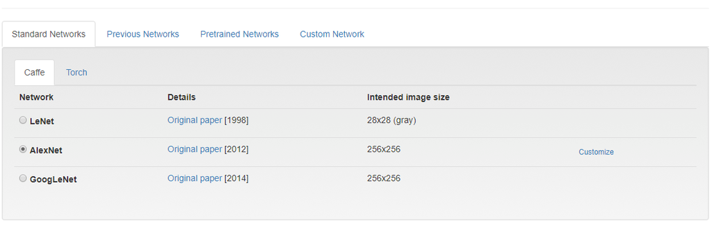

We'll discover the many rules that were set by this choice but you can see when you select it that:  
Rule #1: "AlexNet"는 256X256 (Color) 이미지를 이용해야 한다.

Our dataset "Images of Beagles" meets that requirement. We will explore what about AlexNet sets that rule as we progress through this course by experimenting with **network selection and design.**

먼저 설정해둔 데이터셋 "Images of Beagles"는 AlexNet의 학습 조건을 충족합니다.  
(번역필요) For now, learn about the other rules that we have set by training AlexNet on the dataset "Images of Beagles".  
(지금은 "Images of Beagles" 데이터셋을 이용해 AlexNet을 학습시킴으로써 설정한 다른 규칙에 대해 알아보겠습니다. )

신경망을 학습시키면 **"모델(model)"** 을 얻을 수 있습니다.  
이후에도 학습된 모델을 찾을 수 있도록 아래의 사진처럼 Model Name을 "01.Louie Classifier"로 설정하겠습니다.

모델의 이름을 설정했다면 "Create" 버튼을 눌러 학습을 시작하도록 하겠습니다.

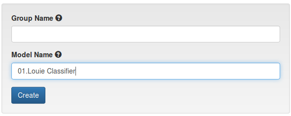

이제 Louie Classifier 모델이 데이터셋의 각 이미지들을 2에폭 동안 모두 살펴보았습니다.  
(신경망)모델이 이미지를 볼 때마다 그 이미지에 각 레이블(Louie, NotLouie)이 포함되어있는지  
혹은 아닌지에 대한 출력(output)이나 예측(prediction)을 생성했습니다.

한번의 예측이 끝나면 (신경망)모델은 정답을 익히고 모델을 조정한 다음 다시 시도합니다.  
이제 학습한 모델이 무엇을 배웠는지 알아보겠습니다.

모델 페이지를 스크롤 할 때 아직은 많은 정보가 없는 그래프를 확인할 수 있고,  
그 아래에 학습한 모델을 시험할 수 있는 Trained Models 섹션을 확인할 수 있습니다.  
"Test a single image" 아래에 "Image Path" 필드에

[output not shown]

위의 내용을 아래의 사진과 같이 입력하겠습니다.

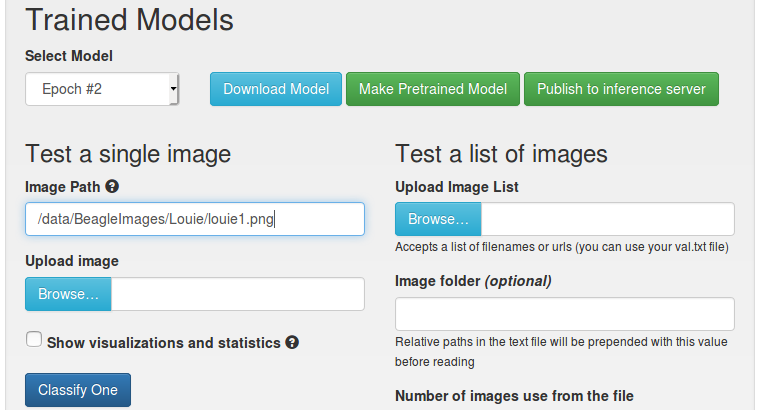

"Classify One" 버튼을 클릭해 그 이미지가 (우연?)(랜덤?)보다 훨씬 나아보이지는 않는 예측을 생성하는 것을 확인할 수 있습니다.

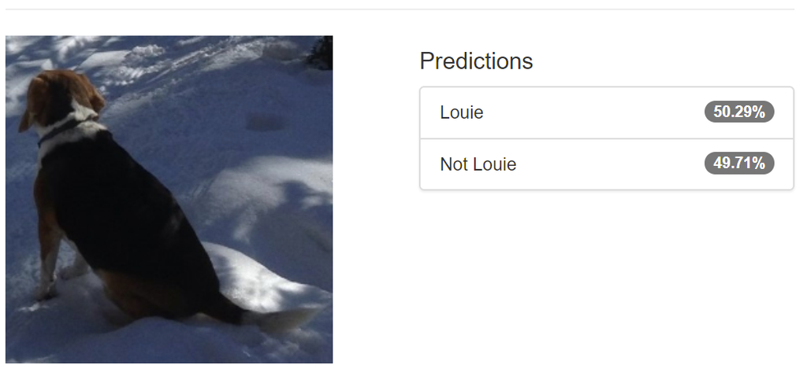

아직은 성능이 좋지 않고 유용한 정보를 제공하는 모델은 아니지만 중요한것은 신경망이 이 게임의 규칙을 이해한다는 것입니다.

한번 더 해보도록 하겠습니다.  
만약 데이터를 몇번 더 보고 암기할 수 있다면 레이블을 더 정확하게 분류할 수 있다고 생각했을 것입니다.  
이 개에 대해 암기하는 것을 배우는 것이 코스의 요점은 아니지만, 신경망을 학습시키는 과정을 볼 수 있을것입니다. 더 많은 에폭으로 다시한번 시도해보겠습니다.

이번에는 100에폭으로 학습시켜보도록 하겠습니다.  
왼쪽 상단의 **DIGITS** 글씨를 클릭해 DIGITS 메인페이지로 이동하겠습니다.  
위에서 학습했던 모델 "Louie Classifier"를 선택하겠습니다.

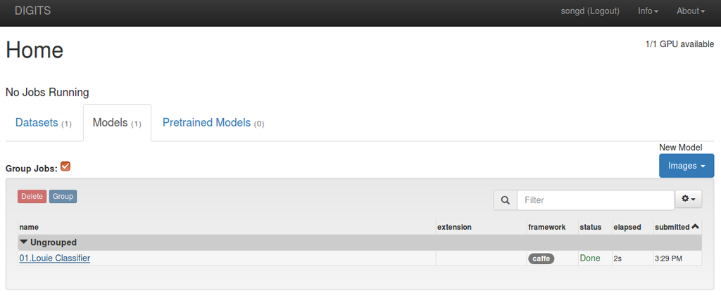

Select "Clone Job" on the right-hand side of the screen to access your training options again. Change the number "Training epochs" to 100.

Scroll to the bottom and give the model a new name:

```
Louie Classifier after 100 Epochs
```

and then "Create".

Note: Because we *cloned* the *job*, all other settings we chose last time persist. We are still training AlexNet with our 16 images of beagles, this time only 100 times instead of 2.

This time, training will take a bit longer (between 3 and 4 minutes). While it trains, examine the two graphs that are generated. They highlight two key concepts that we will examine after this task:

- **loss**
- **learning rate**

Once your model is trained, test the same image in the same way that you did after 2 epochs. Scroll to the bottom of the page to "Trained Models" and then "Test a single image". In the field titled, "Image Path", paste:

```
/dli/data/BeagleImages/Louie/louie1.JPG
```

and select "Classify One".

Congratulations. You have just trained a neural network model by exposing a neural network to data. Feel free to try some other images from the dataset by returning to DIGITS' Home page (selecting the DIGITS logo in the top left corner) and selecting either model.

When satisfied, you may close all tabs with DIGITS and this Jupyter Notebook and return to your course.

The images of Louie can be tested from the paths:

```
/dli/data/BeagleImages/Louie/louie1.JPG
/dli/data/BeagleImages/Louie/louie1.JPG
/dli/data/BeagleImages/Louie/louie2.JPG
/dli/data/BeagleImages/Louie/louie3.JPG
/dli/data/BeagleImages/Louie/louie4.JPG
/dli/data/BeagleImages/Louie/louie5.JPG
/dli/data/BeagleImages/Louie/louie6.JPG
/dli/data/BeagleImages/Louie/louie7.JPG
/dli/data/BeagleImages/Louie/louie8.JPG
```

The images of Not Louie can be tested from the paths:

```
/dli/data/BeagleImages/Not Louie/notlouie1.JPG
/dli/data/BeagleImages/Not Louie/notlouie2.jpg
/dli/data/BeagleImages/Not Louie/notlouie3.JPG
/dli/data/BeagleImages/Not Louie/notlouie4.JPG
/dli/data/BeagleImages/Not Louie/notlouie5.JPG
/dli/data/BeagleImages/Not Louie/notlouie6.JPG
/dli/data/BeagleImages/Not Louie/notlouie7.JPG
/dli/data/BeagleImages/Not Louie/notlouie8.JPG
```

먼저 신경망(인공지능)(네트워크)을 학습시키기 위해서는 레이블 된 데이터가 필요합니다.  
직접 선택한 레이블로 각 레이블 당 이미지 8장 씩 검색하여 바탕화면의 data/FirstDataset 폴더에 각 레이블 폴더를 만들어 저장해 보도록 하겠습니다.  
저는 개,고양이 레이블로 진행하도록 하겠습니다.